# Designing and analyzing ag studies: intro and R example

Agronomy, Crop, Soils Grad Committee

Dr. Leo Bastos, University of Georgia

2024-05-10

## Today’s goals

Explore key concepts in experimentation:

1. Experimentation planning workflow
2. Hypothesis setting
3. Study design = treatment + experimental design
4. CRD vs. RCBD
5. Resources
6. R code

## Experimentation planning workflow

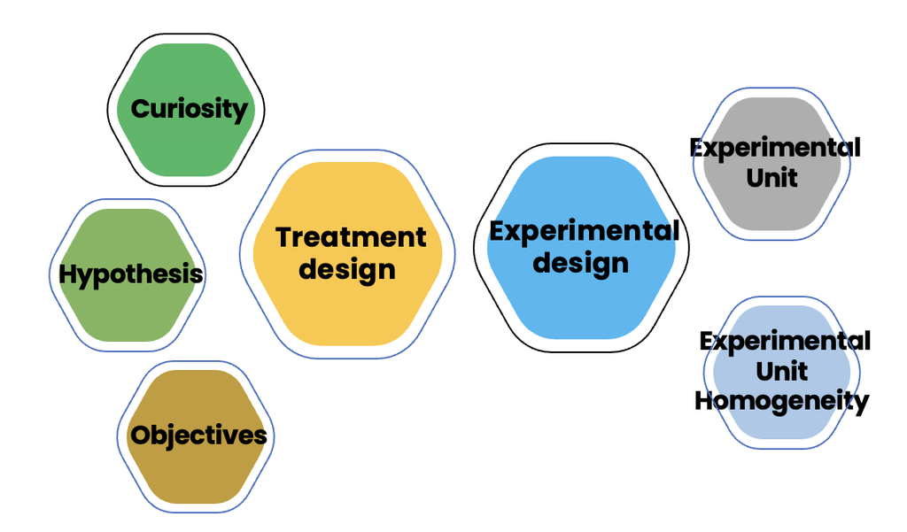

## Working example - Fertilizer rate study

A study was conducted to assess the effect of nitrogen (N) and potassium (K) fertilizer rates on crop yield.

## Hypothesis and Objectives

Your objectives should stem directly from your hypothesis:

> **Hypothesis**: We hypothesize that increasing N and K fertilizer rates will increase crop grain yield.

> **Objectives**: Our objective is to assess the effect of different N and K fertilizer rates on crop grain yield.

## Study design

A study design is comprised of two components:

Treatment design + Experimental design

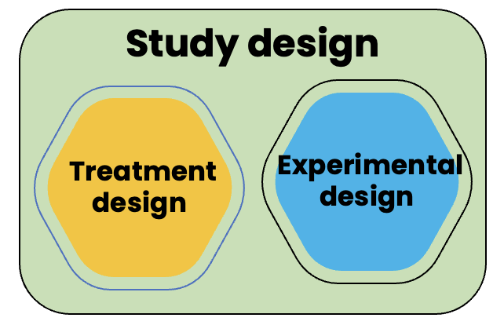

## Treatment design

**Treatment design** is the part of the study design related to what treatments you need to answer your *hypothesis/objectives*, and how they are related to one another.

**Note**

Our goal is to select a treatment design that contains the treatment factors and their respective levels necessary to **properly address the research question(s)**.

Let’s pick 3 levels for each of our factors:

- N fertilizer: 0, 100, 200 kg N/ha
- K fertilizer: 0, 30, 60 kg K/ha

## Treatment design - all levels

- Since we are interested in how N and K interact, we need to have in our treatment design all the combinations between N and K fertilizer levels.
- That leaves us with **3 N levels** x **3 K levels** = **9** total treatment combinations.
- In other words, we need all the above 9 treatments to find the joint optimum N and K fertilizer rates that optimize crop yield.
- This is called a **crossed 2-way factorial** treatment design, or, more informative, **crossed 3 N rate x 3 K rate factorial** treatment design.

## Treatment design - final thoughts

Now, notice that the treatment design has only addressed our objectives.

So what is the use of the experimental design?

## Experimental design

**Experimental design** is the part of the study design related to how your treatments are assigned to the experimental units.

The decision of which experimental design to use should be guided by two factors:

1. Homogeneity of experimental material
2. Limitations such as funds, space in an incubator, size of the benches, size of a field.

## Experimental design

Our goal is to use the **simplest** experimental design that accommodates all our treatments and their replications in **homogeneous experimental units**.

## Experimental design - EU

**Experimental unit (EU)**: the smallest unit in an experiment that is randomly and independently assigned to a treatment, normally is a plot in field research context. Unit of true replication.

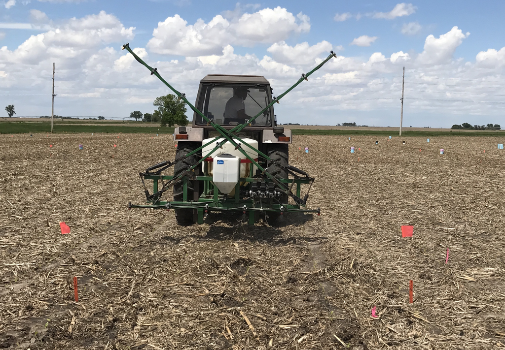

## Experimental design - some concepts

**Replicate**: different experimental units receiving the same treatment. Replicates exist in most designs.

**Block**: a set of experimental units grouped into homogeneous conditions where each EU is randomly assigned to a different treatment, and randomization happens independently for each block.

## Experimental design - some concepts

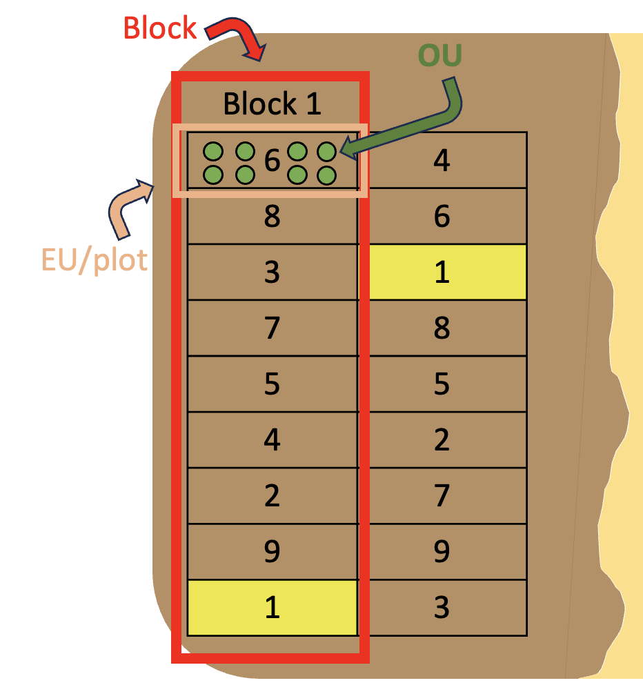

## Experimental design

Continuing with our example of N and K levels, let’s assume that we would like to have **4 replications**.

That brings us to *9 treatments* x *4 replications* = **36 experimental units**.

The question that follows then is

> “Do I have enough homogeneous experimental material to accommodate all 36 experimental units?”.

## Experimental design - some examples

Two of the most common experimental designs in agriculture are:

- Completely randomized design (CRD)
- Randomized complete-block design (RCBD)

## Homogeneous Experimental Material - CRD ✅

> “Do I have enough homogeneous experimental material to accommodate all 36 experimental units?”.

If the answer is **Yes**, then you can use **CRD** as the experimental design, and treatments will be randomized to the **entire area** (no restrictions in randomization).

## Heterogeneous Experimental Material - CRD ❌

> “Do I have enough homogeneous experimental material to accommodate all 36 experimental units?”.

If the answer is **No**, then you should consider what types of limitation you have and which experimental design can be used.

Let’s say we answered **No** in our example. We have enough area to allocate 36 plots on the field, but we know that the area has **heterogeneity in soil texture**, a feature that likely impacts crop yield.

## Heterogeneous Experimental Material - RCBD ✅

- We can acoomodate this by choosing an appropriate experimental design!
- For that, we could use an RCBD, where blocks will be entirely confined within a given soil texture class.

**Note**

With RCBDs, each treatment appears once per block, and a set of 9 different treatments are randomized and assigned to each individual block separately.

## Heterogeneous Experimental Material - RCBD ✅

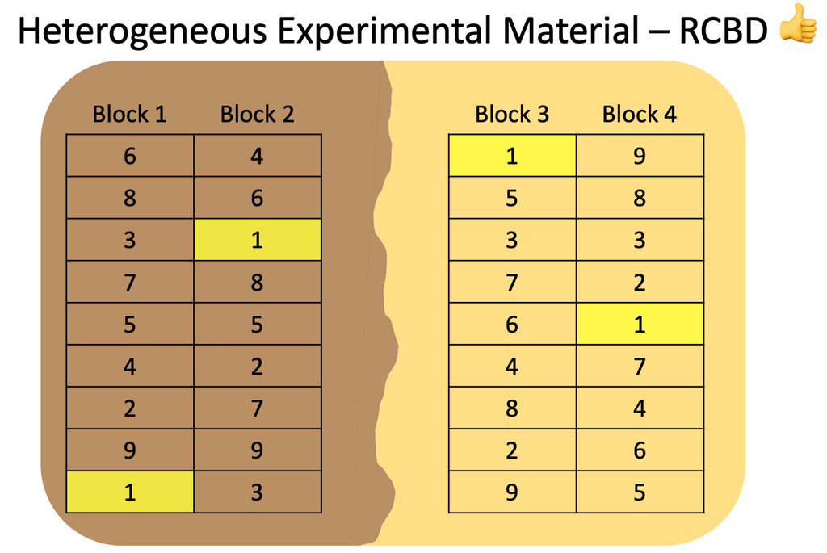

- Note how each treatment appears once and only once in every block.
- The **increased variability** in crop yield caused by **soil texture** will be **confined to the block effect**, and can be properly dissected and not affect our inference on the treatment design variables.

## Summary

- Treatment design: addresses research question(s).
- Experimental design: addresses lack of homogeneity and/or limitations (funds, size, etc.) of experimental material.
- The proper choice of experimental design will allow for unbiased and accurate treatment comparisons.

## Resources

Want to learn more?  
I teach a class at the University of Georgia:

- [Data Science Applied to Ag Schedule with links](https://leombastos.github.io/bastoslab/teaching/2024-dsa/2024-dsa.html)
- **28 videos, 17 R scripts, 12 slide decks**, including
- Intro to R
- CRD
- RCBD
- Split-plot
- Repeated Measure
- git/GitHub
- Open-source data
- Multivariate models
- Machine learning

## Let’s code

Now, let’s analyze data from **3 N rate x 3 K rate** in a **randomized complete block design** that assessed fertilizer rate effect on **crop yield**.